# Assessment2

Yuani

27 September 2015

This is an analysis of the ToothGrowth data in the R datasets package.

#### 1. Load the ToothGrowth data and perform basic exploratory data analyses.

```r
library(datasets)
data("ToothGrowth")
str(ToothGrowth)
```

```
## 'data.frame':    60 obs. of  3 variables:
##  $ len : num  4.2 11.5 7.3 5.8 6.4 10 11.2 11.2 5.2 7 ...
##  $ supp: Factor w/ 2 levels "OJ","VC": 2 2 2 2 2 2 2 2 2 2 ...
##  $ dose: num  0.5 0.5 0.5 0.5 0.5 0.5 0.5 0.5 0.5 0.5 ...
```

```r
head(ToothGrowth)
```

```
##    len supp dose
## 1  4.2   VC  0.5
## 2 11.5   VC  0.5
## 3  7.3   VC  0.5
## 4  5.8   VC  0.5
## 5  6.4   VC  0.5
## 6 10.0   VC  0.5
```

#### 2. Provide a basic summary of the data.

There are 60 observations, with 3 variables in this dataset. The 3 variables are len (Length), supp (Supplpement) and dose (dosage). Based on the varaibles available in this dataset, we hypothesize that the data was derived from an experiment done to measure the effects of Supplements and their dosages on the length of tooth grow.

The summary of the data set by each variable is as follow:

```r
summary(ToothGrowth)
```

```
##       len        supp         dose
##  Min.   : 4.20   OJ:30   Min.   :0.500
##  1st Qu.:13.07   VC:30   1st Qu.:0.500
##  Median :19.25           Median :1.000
##  Mean   :18.81           Mean   :1.167
##  3rd Qu.:25.27           3rd Qu.:2.000
##  Max.   :33.90           Max.   :2.000
```

We explore the data set to test for relationships between the variables.

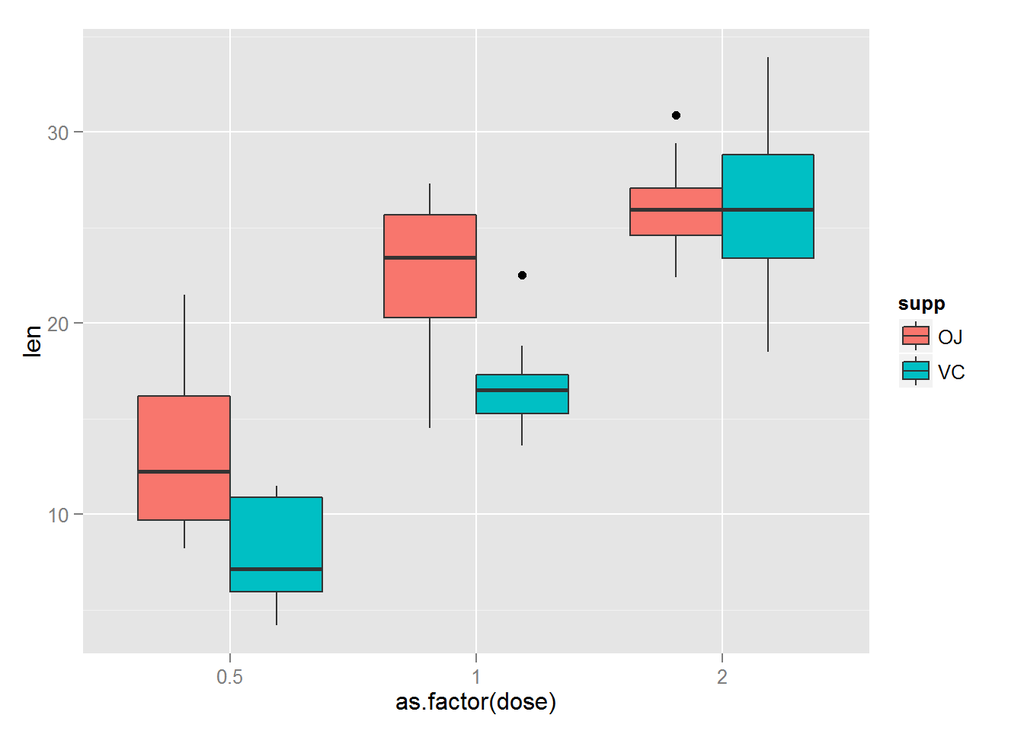

```r
library(ggplot2)
plot1<- plot1<-ggplot(ToothGrowth, aes(x = as.factor(dose), y = len,fill=supp))+geom_boxplot()
plot1
```

#### 3. Use confidence intervals and/or hypothesis tests to compare tooth growth by supp and dose.

##### By Supplement

To test the effect of each supplement on tooth growth, we develop a null hypothesis where each supplement has the same effect on tooth growth for a given dosage.

$H_01: \mu_{OJ|0.5} = \mu_{VC_|0.5}$ $H_02: \mu_{OJ|1.0} = \mu_{VC_|1.0}$ $H_03: \mu_{OJ|2.0} = \mu_{VC_|2.0}$

```r
dose0.5 <- subset(ToothGrowth, dose == 0.5)
dose1.0 <- subset(ToothGrowth, dose == 1.0)
dose2.0 <- subset(ToothGrowth, dose == 2.0)

t0.5 <-t.test(len~supp,paired=FALSE,var.equal=FALSE,data=dose0.5)
t1.0 <-t.test(len~supp,paired=FALSE,var.equal=FALSE,data=dose1.0)
t2.0 <-t.test(len~supp,paired=FALSE,var.equal=FALSE,data=dose2.0)
```

We evaluate the t-test against a confidence interval of 95%.

```r
t0.5$p.value
```

```
## [1] 0.006358607
```

```r
t1.0$p.value
```

```
## [1] 0.001038376
```

```r
t2.0$p.value
```

```
## [1] 0.9638516
```

Based on dosage at 0.5 and 1.0 levels, we reject the null hypothesis ($H_01$ & $H_02$ ) at 95% confidence interval and conclude that OJ supplement contributes to longer tooh grow than VC supplement. Based on dosage at 2.0 levels however, we accept the null hypthesis ($H_03$) at 95% confidence interval and conclude that the type of supplement does not affect the length of the tooth growth.

##### By Dosage

To test the effect of dosage on tooth growth, we develop a null hypothesis where each level of dosage has the same effect on tooth growth for a given supplement.

$H_04: \mu_{0.5|OJ} = \mu_{2.0|OJ}$ $H_05: \mu_{0.5|VC} = \mu_{2.0|VC}$

```r
dose0.5_2.0 <-rbind(dose0.5,dose2.0)
supp_OJ <- subset(dose0.5_2.0, supp == "OJ")
supp_VC <- subset(dose0.5_2.0, supp == "VC")

t_OJ <-t.test(len~dose,paired=FALSE,var.equal=FALSE,data=supp_OJ)
t_VC <-t.test(len~dose,paired=FALSE,var.equal=FALSE,data=supp_VC)
```

We evaluate the t-test against a confidence interval of 95%.

```r
t_OJ$p.value
```

```
## [1] 1.323784e-06
```

```r
t_VC$p.value
```

```
## [1] 4.681577e-08
```

Based on OJ supplement, we reject the null hypothesis ($H_04$) at 95% confidence interval and conclude that a higher dosage results in a longer tooth growth length. Based on VC supplement, we reject the null hypothesis ($H_05$) at 95% confidence interval and conclude that a higher dosage results in a longer tooth growth length.

#### 4. State your conclusions and the assumptions needed for your conclusions.

Using t-testing methods, we conclude that OJ supplement is more effective in contribution to tooth growth then VC supplement. Also, a higher level of dosage of either supplement results in a longer length of tooth growth. However, we note that there may be a cap to the level of effectiveness which a higher level of dosage can drive. As the length of tooth growth for dosage level at 2.0 is almost similar, as shown by $H_03$ results where we were unable to reject the null hypothesis at 95% confidence interval, we may conduct further test and analysis to find how the level of effectiveness diminishes as we continue to increase the level of dosage.